# Untitled

pravesh

17/01/2022

## `ggplot`

1. Using the `mpg`dataset in the `ggplot2` package, replicate the following plot.

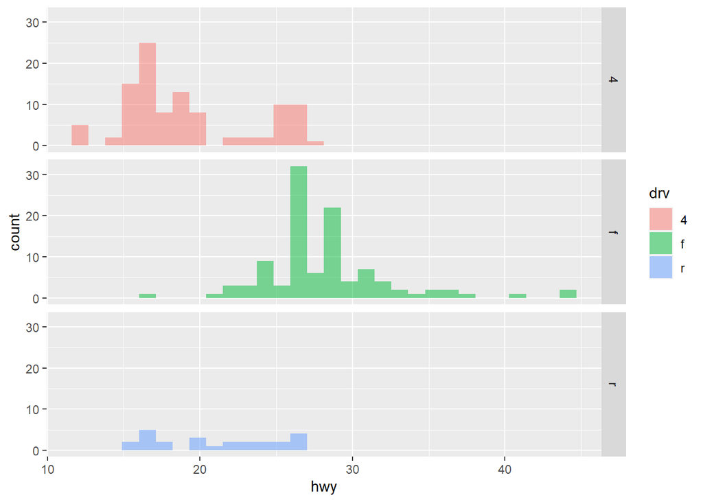

2. Using the `midwest` dataset in the `ggplot2` package, replicate the following plot.

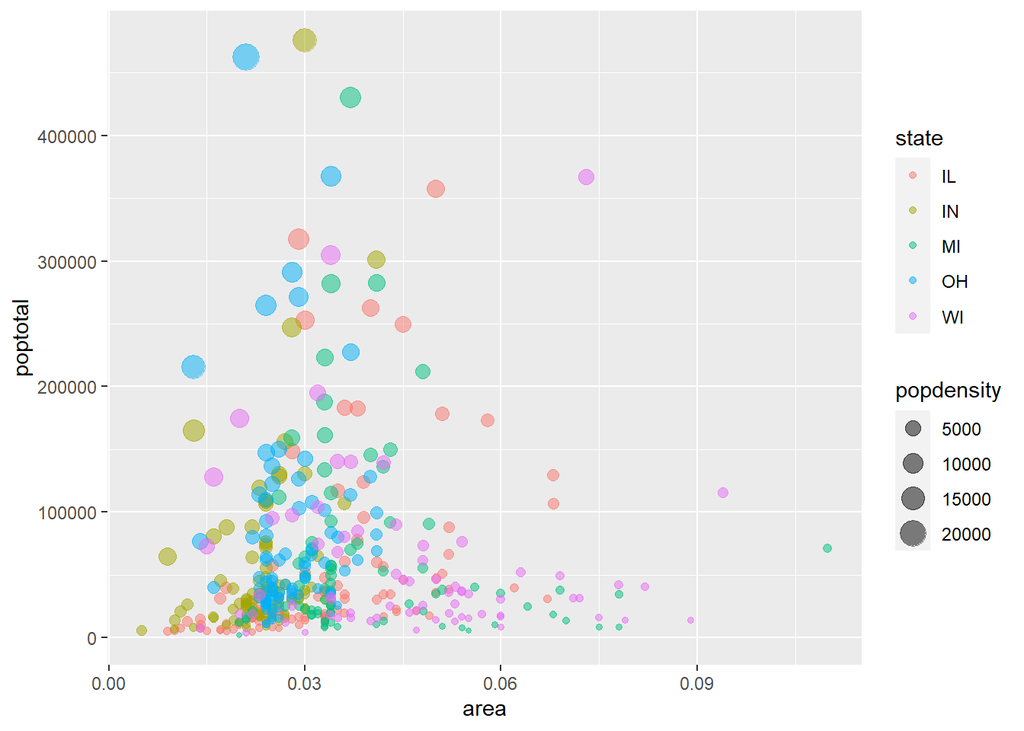

3. Using the `iris` dataset in the base R `datasets` package, replicate the following plot.

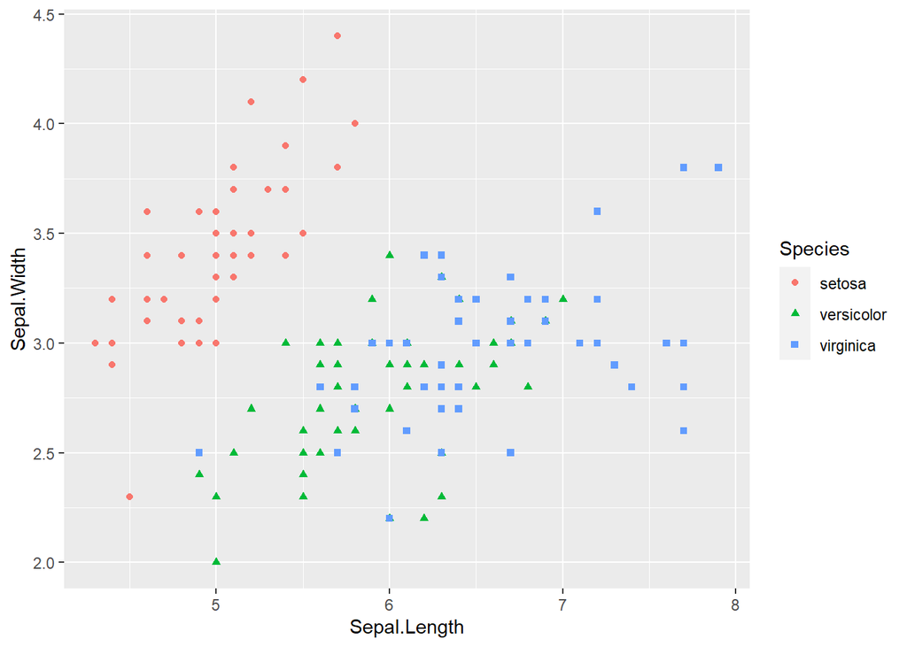

4. Using the `iris` dataset in the base R `datasets` package, replicate the following plot.

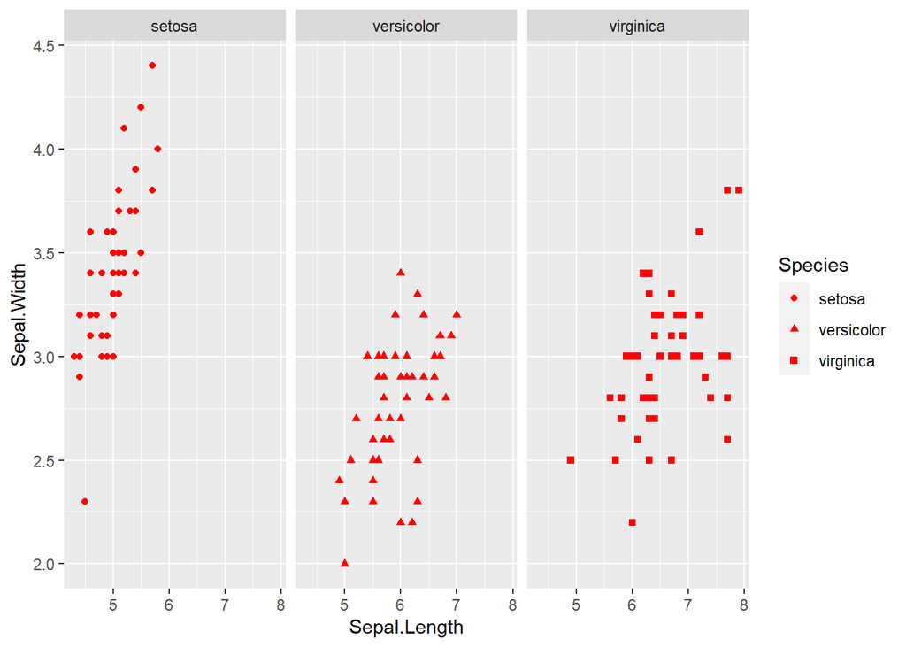

1. Using the `mpg` dataset in the `ggplot2` package, replicate the following plot.

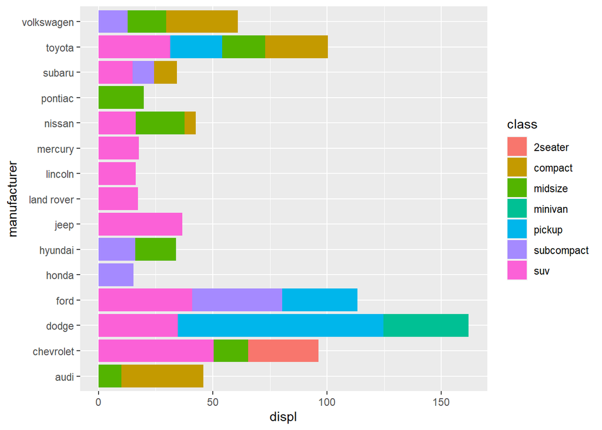

## `dplyr`

1. How many humans are there in the `starwars` dataset in the `dplyr` package?
2. How many female humans are there in the `starwars` dataset in the `dplyr` package ?
3. In the `starwars` dataset in the `dplyr` package, most of the individuals come from which homeworld?
4. What is the mean height of all individuals with orange eyes from the most popular (from which most of the individuals come from) homeworld?
5. What is the standard deviation of height for all droids?
6. Calculate the mean *mpg* (miles per gallon) of the cars with 6 cylinders in `mtcars` dataset in the base R `datasets` package.
7. Which type of transmission (manual or automatic) has a higher variation (standard deviation) of *mpg* in the `mtcars` dataset in the base R `datasets` package?
8. What is the average displacement of a manual car with 4 cylinders in the `mtcars` dataset in the base R `datasets` package?
9. Which specie has the longest and widest petal in the `iris` dataset in the base R `datasets` packages?

## `tidyr`

1. Tidy and replicate the `construction` dataset in the `tidyr` package as given below.

| Year | Month | Region | Completed_Units_Region | Size | Completed_Units_Size |
| --- | --- | --- | --- | --- | --- |
| 2018 | January | Northeast | 114 | 1 unit | 859 |
| 2018 | January | Northeast | 114 | 2 to 4 units | NA |
| 2018 | January | Northeast | 114 | 5 units or more | 348 |
| 2018 | January | Midwest | 169 | 1 unit | 859 |
| 2018 | January | Midwest | 169 | 2 to 4 units | NA |
| 2018 | January | Midwest | 169 | 5 units or more | 348 |
| 2018 | January | South | 596 | 1 unit | 859 |
| 2018 | January | South | 596 | 2 to 4 units | NA |
| 2018 | January | South | 596 | 5 units or more | 348 |
| 2018 | January | West | 339 | 1 unit | 859 |

[output cut: 98 more lines]

1. Tidy and replicate the `fish_encounters` dataset in the `tidyr` package as given below.

   | fish | Release | I80_1 | Lisbon | Rstr | Base_TD | BCE | BCW | BCE2 | BCW2 | MAE | MAW |
   | --- | --- | --- | --- | --- | --- | --- | --- | --- | --- | --- | --- |
   | 4842 | 1 | 1 | 1 | 1 | 1 | 1 | 1 | 1 | 1 | 1 | 1 |
   | 4843 | 1 | 1 | 1 | 1 | 1 | 1 | 1 | 1 | 1 | 1 | 1 |
   | 4844 | 1 | 1 | 1 | 1 | 1 | 1 | 1 | 1 | 1 | 1 | 1 |
   | 4845 | 1 | 1 | 1 | 1 | 1 | NA | NA | NA | NA | NA | NA |
   | 4847 | 1 | 1 | 1 | NA | NA | NA | NA | NA | NA | NA | NA |
   | 4848 | 1 | 1 | 1 | 1 | NA | NA | NA | NA | NA | NA | NA |
   | 4849 | 1 | 1 | NA | NA | NA | NA | NA | NA | NA | NA | NA |
   | 4850 | 1 | 1 | NA | 1 | 1 | 1 | 1 | NA | NA | NA | NA |
   | 4851 | 1 | 1 | NA | NA | NA | NA | NA | NA | NA | NA | NA |
   | 4854 | 1 | 1 | NA | NA | NA | NA | NA | NA | NA | NA | NA |

   [output cut: 9 more lines]

2. Tidy and replicate the `who` dataset in the `tidyr` package as given below.

   | country | iso2 | iso3 | year | Diagnosis | Value |
   | --- | --- | --- | --- | --- | --- |
   | Afghanistan | AF | AFG | 1980 | new_sp_m014 | NA |
   | Afghanistan | AF | AFG | 1980 | new_sp_m1524 | NA |
   | Afghanistan | AF | AFG | 1980 | new_sp_m2534 | NA |
   | Afghanistan | AF | AFG | 1980 | new_sp_m3544 | NA |
   | Afghanistan | AF | AFG | 1980 | new_sp_m4554 | NA |
   | Afghanistan | AF | AFG | 1980 | new_sp_m5564 | NA |
   | Afghanistan | AF | AFG | 1980 | new_sp_m65 | NA |
   | Afghanistan | AF | AFG | 1980 | new_sp_f014 | NA |
   | Afghanistan | AF | AFG | 1980 | new_sp_f1524 | NA |
   | Afghanistan | AF | AFG | 1980 | new_sp_f2534 | NA |

   [output cut: 9990 more lines]

3. Tidy and replicate the `world_bank_pop` dataset in the `tidyr` package as given below.

| country | indicator | Year | Population |
| --- | --- | --- | --- |
| ABW | SP.URB.TOTL | 2000 | 42444.000000000 |
| ABW | SP.URB.TOTL | 2001 | 43048.000000000 |
| ABW | SP.URB.TOTL | 2002 | 43670.000000000 |
| ABW | SP.URB.TOTL | 2003 | 44246.000000000 |
| ABW | SP.URB.TOTL | 2004 | 44669.000000000 |
| ABW | SP.URB.TOTL | 2005 | 44889.000000000 |
| ABW | SP.URB.TOTL | 2006 | 44881.000000000 |
| ABW | SP.URB.TOTL | 2007 | 44686.000000000 |
| ABW | SP.URB.TOTL | 2008 | 44375.000000000 |
| ABW | SP.URB.TOTL | 2009 | 44052.000000000 |

[output cut: 9990 more lines]

1. Tidy and replicate the `population` dataset in the `tidyr` package as given below.

| country | 1995 | 1996 | 1997 | 1998 | 1999 | 2000 | 2001 | 2002 | 2003 | 2004 | 2005 | 2006 | 2007 | 2008 | 2009 | 2010 | 2011 | 2012 | 2013 |
| --- | --- | --- | --- | --- | --- | --- | --- | --- | --- | --- | --- | --- | --- | --- | --- | --- | --- | --- | --- |
| Afghanistan | 17586073 | 18415307 | 19021226 | 19496836 | 19987071 | 20595360 | 21347782 | 22202806 | 23116142 | 24018682 | 24860855 | 25631282 | 26349243 | 27032197 | 27708187 | 28397812 | 29105480 | 29824536 | 30551674 |
| Albania | 3357858 | 3341043 | 3331317 | 3325456 | 3317941 | 3304948 | 3286084 | 3263596 | 3239385 | 3216197 | 3196130 | 3179573 | 3166222 | 3156608 | 3151185 | 3150143 | 3153883 | 3162083 | 3173271 |
| Algeria | 29315463 | 29845208 | 30345466 | 30820435 | 31276295 | 31719449 | 32150198 | 32572977 | 33003442 | 33461345 | 33960903 | 34507214 | 35097043 | 35725377 | 36383302 | 37062820 | 37762962 | 38481705 | 39208194 |
| American Samoa | 52874 | 53926 | 54942 | 55899 | 56768 | 57522 | 58176 | 58729 | 59117 | 59262 | 59117 | 58652 | 57919 | 57053 | 56245 | 55636 | 55274 | 55128 | 55165 |
| Andorra | 63854 | 64274 | 64090 | 63799 | 64084 | 65399 | 68000 | 71639 | 75643 | 79060 | 81223 | 81877 | 81292 | 79969 | 78659 | 77907 | 77865 | 78360 | 79218 |
| Angola | 12104952 | 12451945 | 12791388 | 13137542 | 13510616 | 13924930 | 14385283 | 14886574 | 15421075 | 15976715 | 16544376 | 17122409 | 17712824 | 18314441 | 18926650 | 19549124 | 20180490 | 20820525 | 21471618 |
| Anguilla | 9807 | 10063 | 10305 | 10545 | 10797 | 11071 | 11371 | 11693 | 12023 | 12342 | 12637 | 12903 | 13145 | 13365 | 13571 | 13768 | 13956 | 14132 | 14300 |
| Antigua and Barbuda | 68349 | 70245 | 72232 | 74206 | 76041 | 77648 | 78972 | 80030 | 80904 | 81718 | 82565 | 83467 | 84397 | 85349 | 86300 | 87233 | 88152 | 89069 | 89985 |
| Argentina | 34833168 | 35264070 | 35690778 | 36109342 | 36514558 | 36903067 | 37273361 | 37627545 | 37970411 | 38308779 | 38647854 | 38988923 | 39331357 | 39676083 | 40023641 | 40374224 | 40728738 | 41086927 | 41446246 |
| Armenia | 3223173 | 3173425 | 3137652 | 3112958 | 3093820 | 3076098 | 3059960 | 3047002 | 3036032 | 3025652 | 3014917 | 3002911 | 2989882 | 2977488 | 2968154 | 2963496 | 2964120 | 2969081 | 2976566 |

[output cut: 209 more lines]

https://bookdown.org/sunboklee/ewha_r_2021_1/base-r-quiz.html#quiz-problem-1